# Medicinal Plants

## Why does traditional plant medicine exist?

- **Humans have always searched for substances that relieve suffering and provide cures for loved ones**
- **Mystical agents underlying the natural world were thought to cause illness, thus cures were sought from animals and plants**
  - likely involved a painful process of trial and error
- **Communication among early populations was poor…**
  - slowed accumulation/spread of medical knowledge
  - remedies discovered independently several times

[figure not shown]

## Histories of plants in medicine eventually recorded

- **Earilest known medical document by Sumerians**
  - 4,000 years ago in Mesopotamia
- **Herbal medicines were prevalent in ancient Egypt**
  - mandrake for pain, garlic for heart
  - remedies ‘published’ in Ebers Papyrus
- **Ancient Chinese reveal herbal remedies**
  - Pun-tsao (1600) thousands of herbal remedies
- **Aztecs gifted Badianus manuscript to king of Spain**
  - mesoamerican herbal remedies for 100 afflictions

[figure not shown]

## Ancient Greeks are the foundation of western medicine

- **Greek physician, Hippocrates, Father of Medicine**
  - believed diseases had *natural* causes
  - used various herbal remedies
  - works used for 1500 years!
- **Dioscorides, Roman military physician, wrote ‘De Materia Medica’ describing preparation of 1000 simple drugs**
  - 600 species of plants with medicinal value
  - very inaccurate but became a prototype
- **Herbal remedies by Greeks/Romans have been kept and lost**
  - willow bark tea = precursor to asprin
  - *Ferula* used for contraception but collected to extinction

[figure not shown]

## Age of herbals: Doctrine of Signatures

- **Renaissance age (1500) & printing press created a revival of herbalism**
  - 4 German ‘Fathers of Botany’
  - Gerard, “The herbal of general history of plants”
- **Publishings included medicinal uses & superstitions**
  - Culpepper, “The complete herbal” included astrology
- **Doctrine of Signatures: herbs resembling various parts of the body can be used to treat ailments of those body parts**
  - juice of bloodwort treats blood disorders
  - lobed liverwort treats liver complaints

[figure not shown]

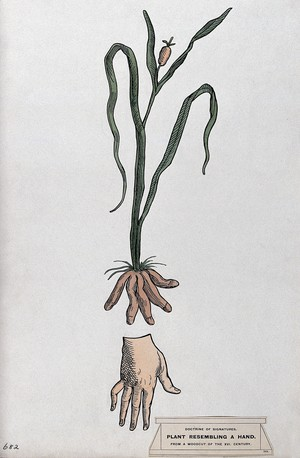

[figure not shown]

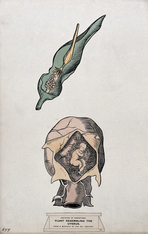

## 17-18th century added experimental approaches

- **Science and philosophy advanced to hypotheses testing stage**
  - helped discredit many previous approaches
- **Improved understanding of human physiology led to more careful testing of medicines**
- **Led to the discovery of vaccinations and documented experiments on plant medicines for heart problems (e.g., foxglove for dropsy)**
  - start of ‘pharamacology’

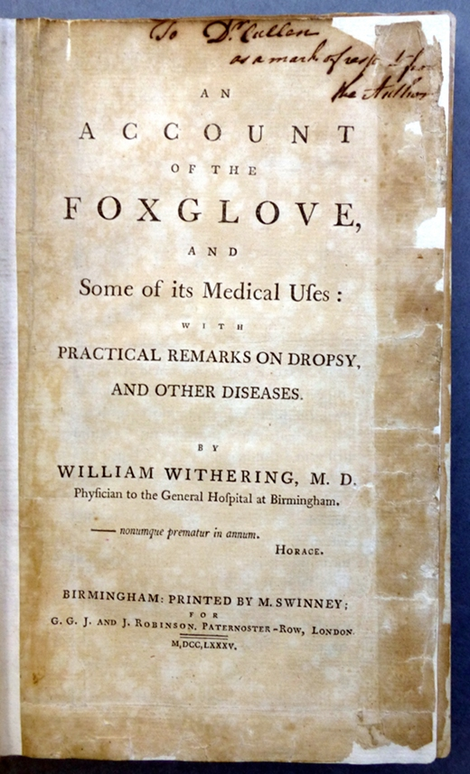

## Modern era prescription drugs

[figure not shown]

- **Herbalism diminished in recent centuries, but remedies still were effective**
  - remedies became ‘prescriptions’ by physicians
  - William Withering, 1775, foxglove for heart failure
  - new standard for pharmaceutical industry
- **Purifying active extracts/synthetics started in 19<sup>th</sup> century**
  - morphine from poppy in 1806
  - Salicyclic acid (many plants) synthesized for pain relief
- **25% of prescriptions today contain plant-derived active ingredients**
  - research still investigating new active compounds
  - e.g. studying ingredients in Native America remedies

## Modern era plant-based medicine

- **First half of 20th century was a period of tremendous advancement as the causes of diseases were uncovered**
- **Initially, many modern medicines were isolated, purified products from traditional plant-derived extracts**
  - morphine, quinine, ephedrine
- **Chemists begin to determine the structures of these active compounds**
  - eventually leads to synthetic synthesis

[figure not shown]

## Reduction in natural remedies post 1950’s

- **Health care workers developed disdain for ‘folk’ based medicine**
  - belief that humans have ‘tested-out’ plants for medicinal value
- **Pharmaceutical companies are now reluctant to undertake massive screening and testing programs to explore for new plant drugs**
  - low ROI
- **Advances in understanding the biochemistry of disease favor design of novel synthetic drugs**

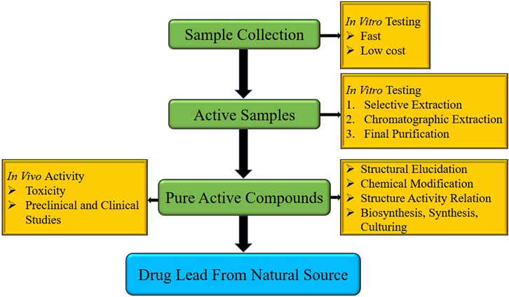

## Is the philosophy of Western medicine a barrier?

- **Western medicine philosophy: emphasis on diagnosis of explicit disease and treatment with with one/few specific compounds**
- **Different practices of medicine treat illnesses more holistically**
  - ailments are manifestations of an imbalance
- **In these alternate practices, plant-based medicine is far more common**
  - in recent decades these approaches have increased in the US/Europe
- **Across approaches to medicine, the role of plant biodiversity remain vital**
  - emerging diseases/strains vs compounds discovered from plants

## National Cancer Institute: Natural Products Discovery Program

**Since 1986, the Developmental Therapeutics Program at NCI has empowered the program to acquire plants and marine organisms through collection contracts**

**Encompasses >25 tropical and subtropical countries worldwide**

- **80k plant samples (green)**
  - 5K unique genera
- **25K marine invertebrates and algae (blue)**
  - 4K unique genera
- **25K microbial samples (brownish)**
  - 1K unique genera
- **over 230,000 unique extracts**

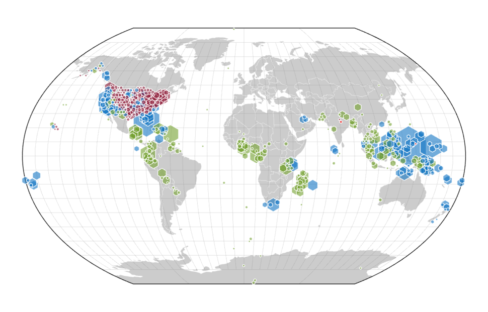

## Herbal medicine today

- **Rural populations still rely on herbal medicine**
  - China, India, S. America, Africa, & Appalachia
  - medicine + supplements industry value = ~250 million
- **Modern Chinese medicine combines herbal, acupuncture & Western medicine**
  - unique health care from 1 billion people
  - thousands of medicinal herbs
- **Modern Indian culture believe in traditional medicine**
  - manufactured pharmaceuticals too expensive
  - reliance on indigenous cures
- **Rainforests are hubs of medical potential, but are decreasing**
  - loss of tribal herbal practices

[figure not shown]

## Active principals in plants

- **Medicine value tied to chemical compounds**
  - manufactured by biochemical pathways
- **Compounds called ‘secondary products’ as they do not directly impact metabolism (growth)**
  - alkaloids, glycosides, terpenes & phenolics
- **Herbivore defense, inhibit fungal or bacteria pathogens**

[figure not shown]

## Alkaloids and Glycosides

- **Alkaloids: diverse compounds found in dicots**
  - analegstics - pain reduction
  - impact animal nervous/muscle systems
  - medicinal, poisonous, hallucinogenic
  - *caffeine, nicotine, cocaine, morphine, quinine*
- **Glycosides: widespread compounds with glucose**
  - cyanogenic or cardioactive glycosides, saponins
  - steroid molecules as active component
  - treat heart failure, can be toxic
  - digitalis, lily of the valley, oleander

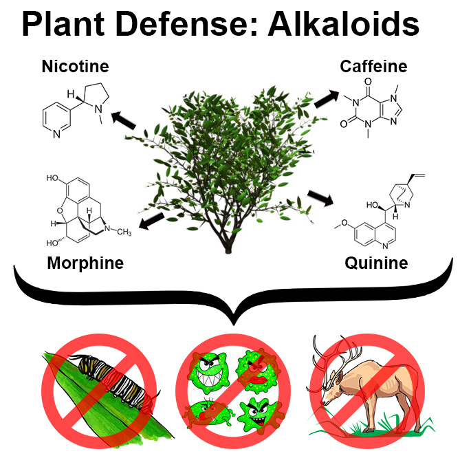

## Medicinal plant case study: Foxglove

- **Foxglove (*digitalis purpurea*) bienneial in snapdragon family**
  - lawn ornamental
  - 30 different glycosides
  - can be very toxic
- **Digitoxin no longer a front-line drug today but still used on hundreds of thousands of patients**
  - thin line between theraputic and toxic
- **In 1775, British physician learned of a folk remedy for dropsy**
  - bloating due to fluid accumulation: congestive heart failure
  - digitalis tea became treatment
  - slows heart rate, increase strength of heartbeat

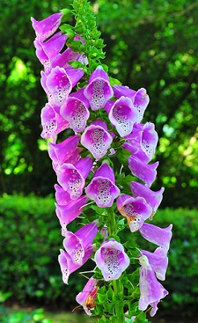

[figure not shown]

## Medicinal plant case study: Willow to aspirin

- **Willow tree bark used for pain reduction in many cultures**
  - ancient Greeks and Native Americans
  - reduces fever and chills
- **Evolution of aspirin began with willow bark experiments in England**
  - 1828, salicin isolated as active ingredient
  - salicin derivatives occur in many species
- **BAYER focused on acetylsalicylic acid from *Spirea* plant**
  - less digestive issues
  - renamed to *aspirin*

[figure not shown]

## Medicinal plant case study: Fever Bark Tree

- **Malaria is one of the worlds most prevalent diseases**
  - 200 million infections each year
  - records of malaria date back to ancient Egyptians
  - female *Anopheles* mosquite w/ *Plasmodium* parasite
- **Fever bark tree was first treatment for malaria**
  - native to east slopes of Andes mtns
  - belongs to coffee family
  - used by Incas to treat fever, then malaria
- **Trade developed for powdered bark**
  - 2lbs to treat one person
  - *quinine* was isolated before over-exploitation
  - now: synthetic cholroquinine

[figure not shown]

## Medicinal plant case study: Ephedra

- **Ephedrine is a plant alkaloid produced by genu *Ephedra***
  - only one genus in the family of gymnosperms
  - native to Americas, Europe, Asia & Africa
- **Long cultural history as a herbal medicine**
  - decongestant and respiratory ailments
- **Ephedrine still found in modern drugs**
  - relaxes bronchial muscles & a CNS stimulant
- **Large scale abuse of herbal *Ephedra* products**
  - herbal ecstasy, similar to amphetamines
  - activates thermogenesis, calorie burning
  - supplements illegal, medications?

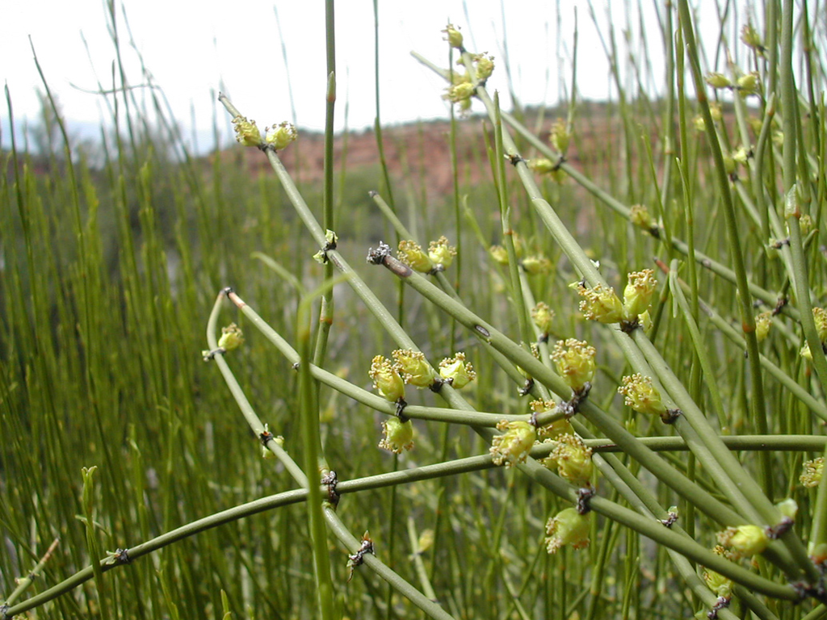

## Medicinal plants and cancer

- **Humans have suffered cancer for 1,000s of years**
  - Ebers Papyrus suggested treatments
  - 2<sup>nd</sup> leading cause of death in US
- **Plants have always featured in folk remedies**
  - search for anticancer plant sources began in 50’s by NCI
  - 1,000s of plants have been screened
  - several now part of chemotherapy treatments
- **Vinca alkaloids for leukemia (Madagascar periwinkle)**
- **Taxol from Pacific yew used in many chemotherapy treatments**
- **Camptotheca from Chinese happy tree for ovarian cancer**

[figure not shown]

## Herbal remedies: promises and problems

- **Plants and plant extracts feature prominently in alternative medicines**
  - considered dietary supplements by FDA
  - multi-billion a year industry
- **Dietary supplements are not subject to FDA approval**
  - no rigorous clinical testing
  - FDA will only take reactionary actions
- **Secondary plant compounds may have health benefits or cause adverse reactions**
  - 40% of US populations uses alternative medicines
  - no clinical linkage to medications

[figure not shown]